title: "2021 SEAK Pink Salmon Forecast " author: "Sara Miller, Rich Brenner, Jim Murphy" date: "November 2, 2020--draft"

# Objective

To forecast the Southeast Alaska (SEAK) pink salmon harvest in 2021.

# Executive Summary

Forecasts were developed using an approach originally described in Wertheimer et al. (2006), and modified in Orsi et al. (2016) and Murphy et al. (2019). We used a similar approach to Murphy et al. (2019) but assumed a log-normal error. This approach is based on a multiple regression model with juvenile pink salmon catch-per-unit-effort (CPUE) and temperature data from the Southeast Alaska Coastal Monitoring Survey (SECM; Murphy et al. 2020). The final model used for the forecast was:

$$E(y) = \alpha + \beta_1{X_1} + \beta_2{X_2} + \epsilon,$$

where $y$ is ln(pink salmon harvest in SEAK), $\beta_1$ is the coefficient for CPUE using the 'pooled' vessel calibration coefficient (see *calibration_coefficient_discussion* document), $\beta_2$ is the coefficient for the environmental covariate water temperature, and $\epsilon$ represents the lognormal error term. The CPUE data are the average log-transformed catches standardized to an effort of a 20 minute trawl set and calibrated to the fishing power of the NOAA Ship *John N. Cobb.* For each year, the standardized catch is either taken from June or July, whichever month had the highest average catches in a given year. Water temperature data is the average (May through July) temperature in the upper 20 m at the eight SECM stations in Icy Strait. This is similar to what has been identified as the Icy Strait Temperature Index ('ISTI'), but historically this index has included May through August temperature data. Based on performance metrics (Akaike Information Criterion corrected for small sample sizes; AICc values; Burnham and Anderson 2004; mean and median absolute percentage error (MAPE, MEAPE); mean absolute scaled error (MASE) (Hyndman and Kohler 2006)) used to evaluate forecast accuracy of alternative vessel calibration coefficients using the same model, the 'pooled' vessel calibration coefficient was used in the following analysis.

Leave-one-out cross validation (hindcast) and model performance metrics were used to evaluate the forecast accuracy of models. These metrics included MAPE, MEAPE, MASE, and AICc. Statistical analyses were performed with the R Project for Statistical computing version 3.6.3 (R Core Team 2020). Based on the AICc, the MASE metric, and significant coefficients in the models, the preferred model (i.e., the additive model with CPUE and temperature; model m2) predicted that the SEAK pink salmon harvest in 2021 will be in the moderate range with a point estimate of 28.5 million fish (80% prediction interval: 19.4 to 41.7 million fish).

# Forecast Models (pink_cal_pooled_species vessel calibration coefficient)

## Analysis

Three hierarchical models were investigated. The full model was model m3:

$$E(y) = \alpha + \beta_1{X_1} + \beta_2{X_2} + \beta_3{X_1X_2},$$

where ${X_1}$ is the average CPUE for catches in either the June or July survey, whichever month had the highest average catches in a given year, and based on the pooled-species vessel calibration coefficent, and ${X_2}$ is the average temperature in Icy Strait in May, June, and July at the eight SECM stations sampled in Icy Strait (Icy Strait and Upper Chatham transects; 'ISTI'), and $\beta_3$ is the interaction term between CPUE and the temperature index. The CPUE data are log-transformed in the model (Table 5; m3). If temperature is actually altering how CPUE is related to abundance it makes sense to restrict the temperature data to the CPUE months in the forecast model (June and July). The month of May is included as there are important migratory dynamics prior to the time juveniles are actually sampled in Icy Strait. In the past, the 'ISTI' variable was the average temperature in the upper 20 m during May through August at the eight SECM stations in Icy Strait. For simplicity, although the definition of the variable has changed, the variable is still called 'ISTI.'

Model m1 only contained the CPUE variable and the model m2 contained CPUE, and a May through July temperature variable ('ISTI'). The regression coefficients CPUE and temperature ('ISTI') were significant in the first two models (m1, m2). The interaction term was not significant in the full model (model m3; Table 5). Therefore, only the first two models will be considered further.

Parameter estimates for the three potential models.

| model | term | estimate | std.error | statistic | p.value |
| --- | --- | --- | --- | --- | --- |
| m1 | (Intercept) | 2.289 | 0.208 | 11.019 | 0.000 |
| m1 | CPUE | 0.438 | 0.071 | 6.157 | 0.000 |
| m2 | (Intercept) | 7.077 | 0.945 | 7.486 | 0.000 |
| m2 | CPUE | 0.507 | 0.050 | 10.176 | 0.000 |
| m2 | ISTI | -0.546 | 0.107 | -5.121 | 0.000 |
| m3 | (Intercept) | 3.832 | 2.321 | 1.651 | 0.115 |
| m3 | CPUE | 1.789 | 0.844 | 2.119 | 0.047 |
| m3 | ISTI | -0.193 | 0.254 | -0.757 | 0.458 |
| m3 | CPUE:ISTI | -0.139 | 0.091 | -1.522 | 0.145 |

The model summary results using the metrics AICc, MAPE, MEAPE, and MASE (Hyndman and Kohler 2006) are shown in Table 6. For all of these metrics, the smallest value is the preferred model. The difference ($\Delta_i$) between a given model and the model with the lowest AICc value and the metric MASE were the primary statistics for choosing appropriate models in this analysis. Models with AICc$\Delta_i$ $\leq$ 2 have substantial support, those in which 4 $\leq$ AICc$\Delta_i$ $\leq$ 7 have considerably less support, and models with AICc$\Delta_i$ > 10 have essentially no support (Burnham and Anderson 2004). These two metrics (AICc, MASE) suggest that model m2 is the preferred models. Model m2 (based on CPUE and average temperature in May through July) was used to forecast the 2021 pink salmon harvest (Figure 1).

Summary of model outputs and forecast error measures.

| model | terms | AdjR2 | AICc | MAPE | MEAPE | MASE |
| --- | --- | --- | --- | --- | --- | --- |
| m1 | CPUE | 0.627 | 30 | 0.116 | 0.105 | 0.399 |
| m2 | CPUE+ISTI | 0.830 | 14 | 0.074 | 0.060 | 0.249 |

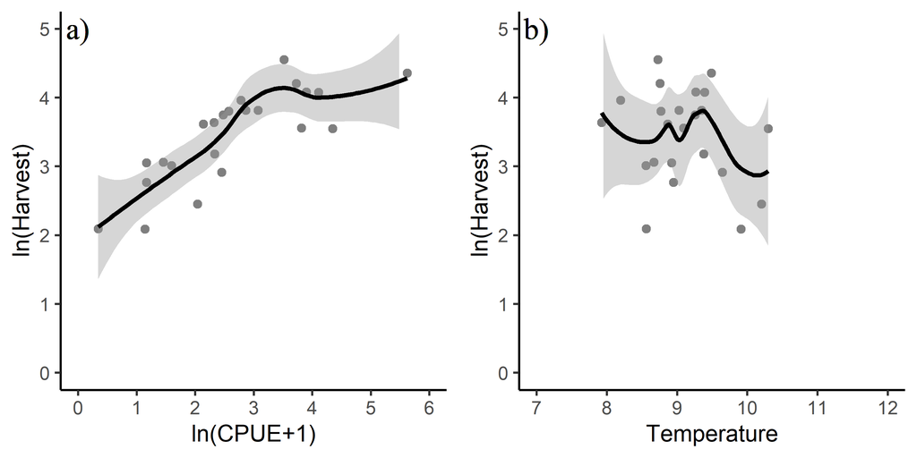

Figure 1: Relationship between a) ln(CPUE+1) and ln(harvest) and b) temperature in May through July (ISTI) and ln(harvest). The line is a smoothing function applied to the relationship with a 95% confidence level interval.

## Model Diagnostics

Model diagnostics for model m2 included residual plots, the curvature test, and influential observation diagnostics using Cook's distance (Cook 1977), the Bonferroni outlier test, and leverage plots. Model diagnostics were used to identify observations that were potential outliers, had high leverage, or were influential (Zhang 2016). These observations may have significant impact on model fitting and may need to be excluded.

### Cook's Distance

Cook's distance is a measure of influence, or the product of both leverage and outlier. Cook's distance,
$$D_i=\ \frac{e_{PSi}^2}{k+1}\ast\frac{h_i}{1-h_i},$$
where $e_{PSi}^2$ is the standardized Pearson residuals, $h_i$ are the hat values (measure of leverage), and $k$ is the number of predictor variables in the model, is a measure of overall influence of the $i_{th}$ data point on all $n$ fitted values (Fox and Weisburg 2019). A large value of Cook's distance indicates that the data point is an influential observation. Cook's distance values greater than $4/(n-k-1)$, where $n$ is the number of observations (i.e., 23), was used as a benchmark for identifying the subset of influential observations (Ren et al. 2016). Therefore, a Cook's distance cut-off of 0.20 was used; observations with a Cook's distance greater than 0.20 were investigated further.

### Leverage

An observation that is distant from the average covariate pattern is considered to have high leverage. If an individual observation has a leverage value $h_i$ greater than 2 or 3 times $p/n$ (Ren et al. 2016), it may be a concern (where $p$ is the number of parameters in the model including the intercept (i.e., 3), and $n$ is the number of observations in the model (i.e., 23); $p/n$ = 3/23 = 0.13 for this study). Therefore, a leverage cut-off of 0.26 was used; observations with a leverage value greater than 0.26 were investigated further.

### Residuals vs. Fitted Plot

The characteristics of an unbiased residual vs. fitted plot and what they suggest about the appropriateness of the simple linear regression model include:

1. The residuals "bounce randomly" around the 0 line. This suggests that the assumption that the relationship is linear is reasonable;
2. The residuals roughly form a "horizontal band" around the 0 line. This suggests that the variances of the error terms are equal; and
3. No one residual "stands out" from the basic random pattern of residuals. This suggests that there are no outliers.

The above paragraph was taken almost directly from the source: https://newonlinecourses.science.psu.edu/stat462/node/117/.

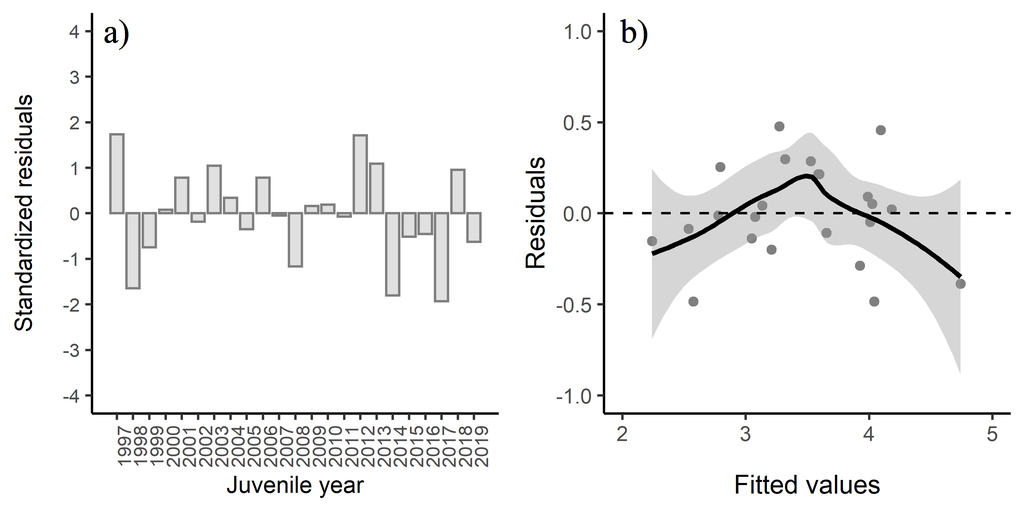

Figure 2: a) Standardized residuals versus juvenile year and b) residuals versus fitted values for model m2. Positive residuals indicate that the observed harvest was larger than predicted by the model.

### Residuals vs. Predictor Plots

The interpretation of a "residuals vs. predictor plot" is identical to that for a "residuals vs. fits plot." That is, a "well-behaved" plot will bounce randomly and form a roughly horizontal band around the residual = 0 line. In addition, no data points will stand out from the basic random pattern of the other residuals. The above paragraph was taken directly from the source: https://newonlinecourses.science.psu.edu/stat462/node/117/.

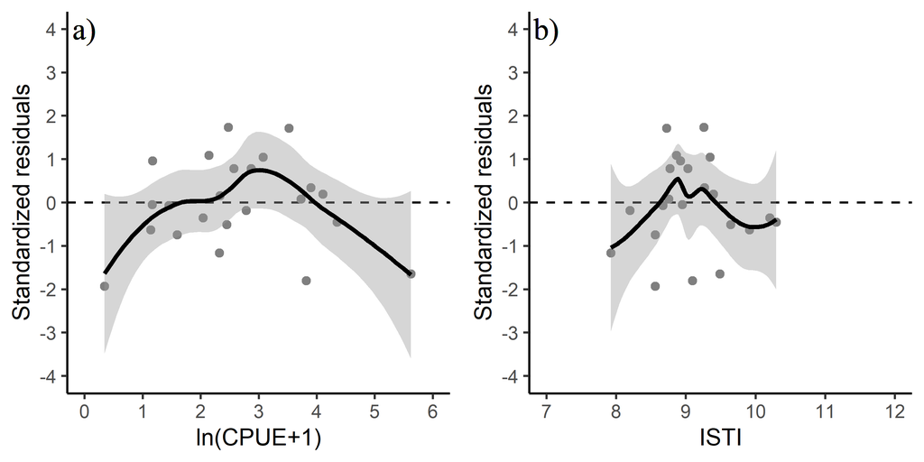

Figure 3: Standardized residuals versus predicted plots for a) CPUE and b) temperature.

### Influential Datapoints

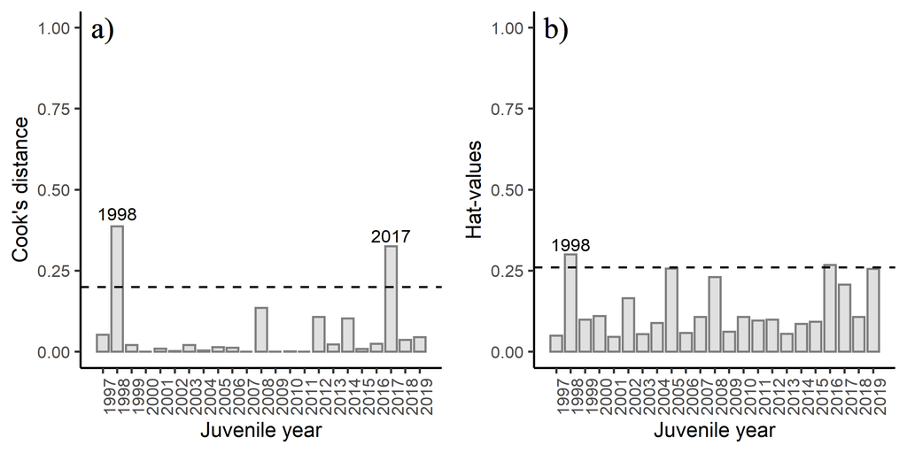

Figure 4: Diagnostics plots of influential observations including a) Cook's Distance (with a cut-off value of 0.20), and b) leverage values (with a cut-off value of 0.26) from model m2.

| year | juvenile_year | SEAKCatch | CPUE | ISTI | resid | hat_values | Cooks_distance | std_resid | fitted |
| --- | --- | --- | --- | --- | --- | --- | --- | --- | --- |
| 1998 | 1997 | 42.5 | 2.478 | 9.259 | 0.476 | 0.049 | 0.052 | 1.737 | 3.273 |
| 1999 | 1998 | 77.8 | 5.622 | 9.489 | -0.387 | 0.300 | 0.387 | -1.645 | 4.741 |
| 2000 | 1999 | 20.3 | 1.598 | 8.560 | -0.199 | 0.099 | 0.021 | -0.747 | 3.210 |
| 2001 | 2000 | 67.0 | 3.730 | 8.756 | 0.022 | 0.110 | 0.000 | 0.082 | 4.183 |
| 2002 | 2001 | 45.3 | 2.869 | 9.028 | 0.215 | 0.046 | 0.010 | 0.784 | 3.598 |
| 2003 | 2002 | 52.5 | 2.785 | 8.198 | -0.048 | 0.165 | 0.002 | -0.188 | 4.009 |
| 2004 | 2003 | 45.3 | 3.078 | 9.349 | 0.285 | 0.054 | 0.021 | 1.043 | 3.528 |
| 2005 | 2004 | 59.1 | 3.899 | 9.269 | 0.091 | 0.089 | 0.004 | 0.338 | 3.988 |
| 2006 | 2005 | 11.6 | 2.040 | 10.203 | -0.085 | 0.256 | 0.014 | -0.352 | 2.536 |
| 2007 | 2006 | 44.8 | 2.573 | 8.771 | 0.214 | 0.058 | 0.013 | 0.785 | 3.588 |
| 2008 | 2007 | 15.9 | 1.168 | 8.951 | -0.012 | 0.108 | 0.000 | -0.046 | 2.778 |
| 2009 | 2008 | 38.0 | 2.323 | 7.925 | -0.287 | 0.231 | 0.136 | -1.164 | 3.925 |
| 2010 | 2009 | 24.0 | 2.333 | 9.378 | 0.043 | 0.061 | 0.001 | 0.158 | 3.135 |
| 2011 | 2010 | 58.9 | 4.108 | 9.395 | 0.051 | 0.107 | 0.001 | 0.191 | 4.025 |
| 2012 | 2011 | 21.3 | 1.455 | 8.669 | -0.019 | 0.096 | 0.000 | -0.071 | 3.078 |
| 2013 | 2012 | 94.7 | 3.522 | 8.725 | 0.457 | 0.099 | 0.107 | 1.712 | 4.094 |
| 2014 | 2013 | 37.2 | 2.143 | 8.865 | 0.297 | 0.055 | 0.023 | 1.088 | 3.319 |
| 2015 | 2014 | 35.1 | 3.817 | 9.093 | -0.485 | 0.086 | 0.102 | -1.804 | 4.043 |
| 2016 | 2015 | 18.4 | 2.453 | 9.645 | -0.138 | 0.092 | 0.009 | -0.514 | 3.050 |
| 2017 | 2016 | 34.7 | 4.351 | 10.297 | -0.109 | 0.268 | 0.025 | -0.452 | 3.655 |
| 2018 | 2017 | 8.1 | 0.346 | 8.560 | -0.484 | 0.207 | 0.325 | -1.933 | 2.576 |
| 2019 | 2018 | 21.1 | 1.172 | 8.925 | 0.255 | 0.107 | 0.037 | 0.959 | 2.795 |
| 2020 | 2019 | 8.1 | 1.142 | 9.911 | -0.153 | 0.255 | 0.045 | -0.630 | 2.241 |

## Results

The best regression model based on the AICc value, the MASE metric, and significant coefficients in the model was model m2 (i.e., the model containing CPUE, and a May through July temperature variable). The adjusted $R^2$ value for model m2 was 0.83 (Table 6) indicating overall a good model fit.

## Conclusion

Based upon a model that includes juvenile pink salmon CPUE and May-July temperature (model m2), the 2021 SEAK pink salmon harvest in 2021 is predicted to be in the moderate range with a point estimate (model mean) of 28.5 million fish (80% prediction interval: 19.4 to 41.7 million fish).

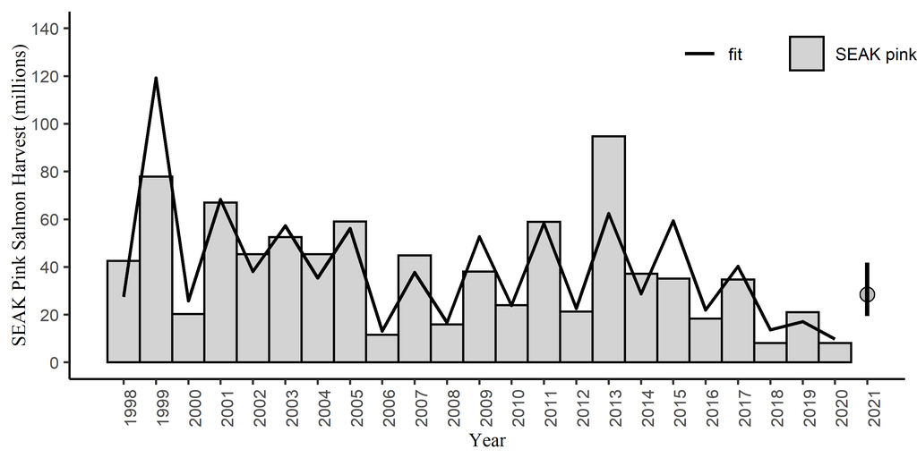

Figure 5: SEAK pink salmon harvest (millions) by year with the model fit (line). The predicted 2021 forecast is symbolized as a grey circle with an 80% prediction interval (19.4 to 41.7 million fish).

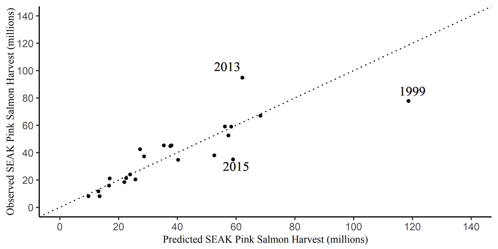

Figure 6: SEAK pink salmon harvest (millions) against the fitted values from model m2 by year. The dotted line is a one to one line.

# References

Burnham, K. P., and D. R. Anderson. 2004. Multimodel inference: Understanding AIC and BIC in model selection. Sociological Methods and Research 33: 261-304.

Cook, R. D. 1977. Detection of influential observations in linear regression. Technometrics 19: 15-18.

Fox, J. and S. Weisburg. 2019. An R Companion to Applied Regression, Third Edition. Thousand Oaks CA: Sage Publications, Inc.

Hyndman, R. J. and A. B. Koehler. 2006. Another look at measures of forecast accuracy. International Journal of Forecasting 22: 679-688.

Murphy, J. M., E. A. Fergusson, A. Piston, A. Gray, and E. Farley. 2019. Southeast Alaska pink salmon growth and harvest forecast models. North Pacific Anadromous Fish Commisson Technical Report No. 15: 75-81.

Orsi, J. A., E. A. Fergusson, A. C. Wertheimer, E. V. Farley, and P. R. Mundy. 2016. Forecasting pink salmon production in Southeast Alaska using ecosystem indicators in times of climate change. N. Pac. Anadr. Fish Comm. Bull. 6: 483–499. (Available at https://npafc.org) R Core Team. 2020. R: A language and environment for statistical computing. R Foundation for Statistical Computing, Vienna, Austria. URL: http://www.r-project.org/index.html

Ren, Y. Y., L. C. Zhou, L. Yang, P. Y. Liu, B. W. Zhao, and H. X. Liu. 2016. Predicting the aquatic toxicity mode of action using logistic regression and linear discriminant analysis. SAR and QSAR in Environmental Research 27(9). DOI: 10.1080/1062936X.2016.1229691

Wertheimer A. C., J. A. Orsi, M. V. Sturdevant, and E. A. Fergusson. 2006. Forecasting pink salmon harvest in Southeast Alaska from juvenile salmon abundance and associated environmental parameters. In Proceedings of the 22nd Northeast Pacific Pink and Chum Workshop. Edited by H. Geiger (Rapporteur). Pac. Salmon Comm. Vancouver, British Columbia. pp. 65–72.

Zhang, Z. 2016. Residuals and regression diagnostics: focusing on logistic regression. Annals of Translational Medicine 4: 195.